# Heaven On Earth Massage

BYU-Idaho Consulting Project (MATH325)

Andrew Seaman

03/16/2026

```r
# Import libraries
pacman::p_load( ggplot2, ggridges, readr, mosaic, directlabels, DT, lubridate, pander, plotly, tidyverse)

# Import dataset
mssg <- read_csv("../Data/massage.csv", col_types = "dcccdcdcddddd") %>%
  rename(
    week = "Week",
    date = "Date",
    staff = "Staff",
    client = "Client",
    description = "Description",
    length_min = "Length (min)",
    base_amt = "Base Amt ($)",
    discount_pct = "Discount (%)",
    discount_amt = "Discount ($)",
    paid_amt = "Paid Amt ($)",
    tip_amt = "Tip Amt ($)",
    total_amt = "Total Amt ($)"
  ) %>%
  # Add calculated columns & Clean data types
  mutate(
    length_hr = length_min/60,
    discount_pct = readr::parse_number(discount_pct) / 100,
    day = substr(date,1,3),
    date = lubridate::mdy(substr(date, 5, nchar(date)))
  )
```

### Data Exploration

#### Uniqe values

Show all unique values by column.

```r
unique_column_value_lists <- mssg %>%
  summarise(across(everything(), ~ paste(unique(.), collapse = ", "))) %>%
  pander()

unique_column_value_lists
```

Table continues below

| week | date | staff |
| --- | --- | --- |
| 27, 28, 29, 30, 35, 32, 33, 34, 36, 37, 38, 39, 40, 41, 42, 43, 44, 45, 46, 47, 48, 49, 50, 51, 52, 53, 1, 2, 3 | 2025-07-02, 2025-07-03, 2025-07-04, 2025-07-08, 2025-07-09, 2025-07-10, 2025-07-11, 2025-07-13, 2025-07-16, 2025-07-17, 2025-07-24, 2025-07-25, 2025-07-26, 2025-08-26, 2025-08-27, 2025-08-28, 2025-08-… | Luke, Christina, Emma, Katrina, Ellie, NA |

Table continues below

| client | length_min |
| --- | --- |
| Heather Burton, Avanlee Jessop, Christina Johnson, Luana Oliveira, Camila Smith, Amy Jo Yates, Des Prestwich, Anne Marie Hatch, Debbi Myers, Hanna Owens, SR, Gigi, Megan Luke, Jennifer Davis, Ian, deb… | 90, 120, NA, 60, 75, 80, 110 |

Table continues below

| description | base_amt |
| --- | --- |
| NA, HOT STONE PLUS CUPPING, SR Employee Tyler Holt, SR, Hot Stones, Couples, 60 gift card, Couples 60, Ian, 60, SR 2 clients, SR 2 Clients, #NAME?, 2 SR, Promo giveaway massage, promo giveaway massage… | 150, 180, 165, 145, 100, 107.5, 132.5, 210, 110, 105, 80, 75, 135, 155, 115, 117.5, 315, 120, 420, 125, 200, 190, 70, 140, 185, 72.5, 65, 45, 160, 40, 85, 122.5 |

Table continues below

| discount_pct | discount_amt |
| --- | --- |
| 0, 0.4, 0.3, 0.35, 0.5, 0.15, 0.2, 0.25, 1 | 0, 72, 45, 30, 60, 35, 50, 66, 15, 20, 25, 39, 27, 150, 38, 23 |

Table continues below

| paid_amt | tip_amt |
| --- | --- |
| 150, 108, 105, 165, 145, 70, 90, 100, 107.5, 65, 50, 66.25, 85, 210, 110, 80, 180, 75, 135, 116.25, 80.63, 115, 117.5, 315, NA, 120, 420, 125, 200, 190, 155, 140, 185, 69.88, 92, 72.5, 45, 160, 40, 12… | NA, 10.5, 10, 15, 17, 20, 27.75, 22, 16, 30, 27, 43, 21.5, 23.5, 36, 17.5, 20.25, 25, 50, 35, 18.75, 37, 21, 5, 14, 14.5, 9.75, 28, 18.37 |

Table continues below

| total_amt | length_hr |
| --- | --- |
| 150, 108, 105, 175.5, 145, 155.5, 70, 80, 100, 124.5, 75, 110.5, 94, 95, 210, 132, 130, 96, 180, 90, 207, 115, 160, 155, 159.25, 102.13, 133.5, 141, 216, 315, 125, NA, 30, 420, 162, 155.25, 10, 85, 13… | 1.5, 2, NA, 1, 1.25, 1.33333333333333, 1.83333333333333 |

| day |
| --- |
| Wed, Thu, Fri, Tue, Sun, Sat, Mon |

Show a table of counts of unique values by column.

```r
# table_of_counts_all_columns <- mssg %>%
#   tidyr::pivot_longer(everything(), names_to = "column", values_to = "value") %>%
#   dplyr::count(column, value)
#
# table_of_counts_all_columns
```

#### Plots

Pepare a table of counts and convert it into a dataframe. (This is most likley a very inefficient way to wrangle this data).

```r
tbl_counts <- table(mssg$staff, mssg$week)
df_counts <- as.data.frame(tbl_counts) %>%
  rename(
    staff = Var1,
    week = Var2,
    count = Freq
  ) %>%
  mutate(
    staff = as.character(staff),
    weeks = as.numeric(week)
  )
```

**Plot 1:** Horizontal line plot of massages given per week from 2025-2026.

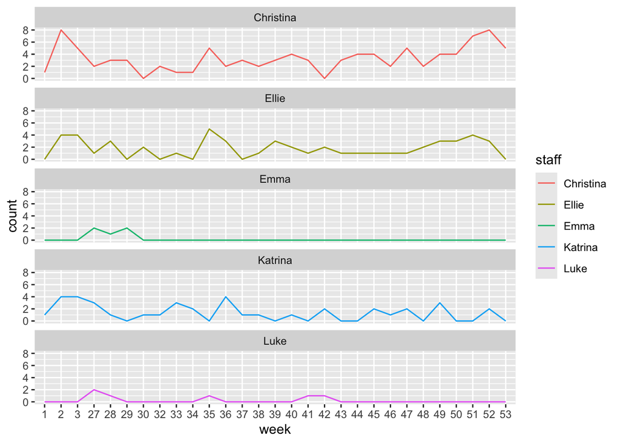

```r
# 1 col, 5 rows
ggplot(df_counts, aes(x=week, y=count, color=staff, group=1))+
  geom_line()+
  facet_wrap(~staff, ncol = 1)
```

**Plot 2:** Vertical line plot of massages given per week from 2025-2026.

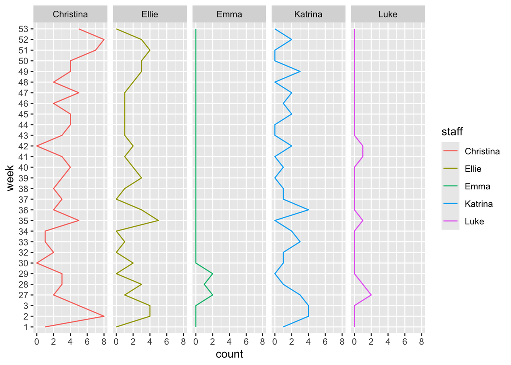

```r
# 5 cols, 1 row
ggplot(df_counts, aes(x=week, y=count, color=staff, group=1))+
  geom_line()+
  facet_wrap(~staff, ncol = 5)+
  coord_flip()
```

**Plot 3:** Ridge plot of massages given per week from 2025-2026.

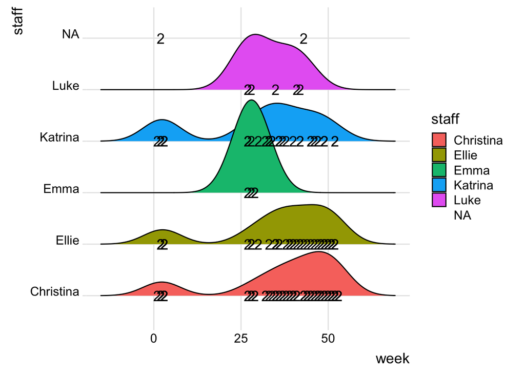

```r
# Ridge Plot
# ggplot(df_counts, aes(x=week, y=staff, fill ))+
#   geom_density_ridges()


ggplot(mssg, aes(x=week, y=staff, fill = staff))+
  geom_density_ridges()+
  theme_ridges()+
  geom_text(aes(label= count(week)))
```

**Plot 4:** Clean ridge plot marking the mean and median of massages given in 2025-2026.

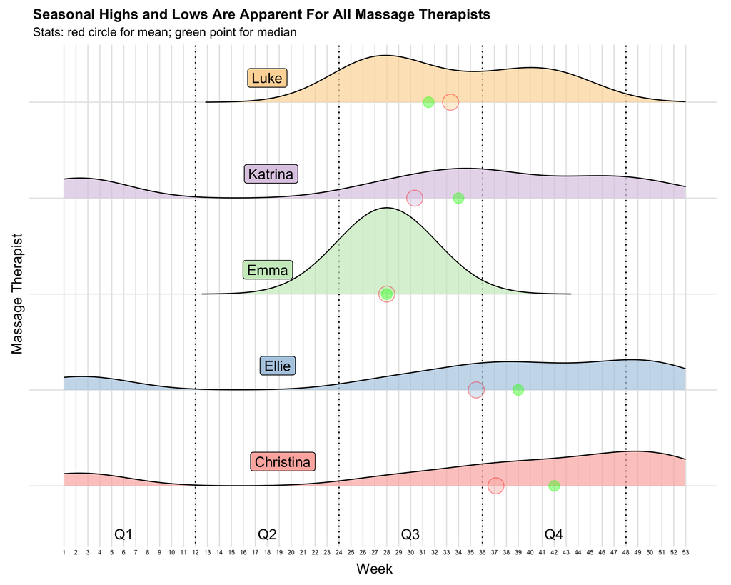

```r
mssg_clean <- mssg %>%
  filter(!is.na(staff), !is.na(week))

week_counts <- mssg_clean %>%
  count(staff, week)

max_week <- max(mssg$week)
fill_colors <- palette.colors(n = 5, palette = palette.pals()[8])

# FAVORITES: ["Tableau 10", "", "", "", ""]
#  [1] "R3"              "R4"              "ggplot2"         "Okabe-Ito"       "Accent"          "Dark 2"
#  [7] "Paired"          "Pastel 1"        "Pastel 2"        "Set 1"           "Set 2"           "Set 3"
# [13] "Tableau 10"      "Classic Tableau" "Polychrome 36"   "Alphabet"

ggplot(mssg_clean, aes(x = week, y = staff, fill = staff)) +
  labs(
    title = "Seasonal Highs and Lows Are Apparent For All Massage Therapists",
    subtitle = "Stats: red circle for mean; green point for median",
    x = "Week",
    y = "Massage Therapist"
  ) +

  # Geom - Section:
  geom_vline(xintercept = c(12, 24, 36, 48), linetype = "dotted", show.legend = FALSE) +
  geom_density_ridges(
    scale = .9,
    alpha = 0.7,
    color = "black",
    rel_min_height = .001
  ) +
  geom_point(
    # pch = 20,
    shape = 21,
    size = 7,
    alpha = .4,
    stat = "summary",
    fun = mean,
    color = "red"
  ) +
  geom_point(
    pch = 20,
    size = 7,
    alpha = .4,
    stat = "summary",
    fun = median,
    color = "green"
  ) +
  geom_label(
    aes(label = staff),
    stat = "summary",
    fun = median,
    vjust = -.8,
    hjust = c(4.7, 7.3, 2.9, 4, 4.6)) +

  annotate("text", x = c(6,18,30,42), y = .5, label = c("Q1", "Q2", "Q3", "Q4"))+

  # Scale - Section:
  scale_x_continuous(limits = c(1,53), breaks = seq(1,53, by = 1)) +
  scale_fill_manual(values = fill_colors) +

  # Theme - Section:
  theme_ridges() +
  theme(
    legend.position = "none",
    axis.text.x = element_text(size = 6),
    axis.text.y = element_blank(),
    # NOTE: `theme_ridges()` may be interfering with the following line of code.
    # axis.title = element_text(hjust = 0.5),
    axis.title.x = element_text(hjust = 0.5),
    axis.title.y = element_text(hjust = 0.5)
  )
```